# llmTest

**Este notebook contém uma proposta de solução para o case. Aqui são mostradas as transformações e enriquecimentos realizados nos dados. Uma proposta de análise é mostrada ao final do tratamento dos dados.**

O notebook foi dividido em 2 partes. As etapas da parte 1 estão listadas a seguir:

1. Importação das bibliotecas necessárias e leitura dos dados.
2. Enriquecimento dos dados usando agrupamentos hierárquicos de CNAE(fonte: IBGE).
3. Transformações aplicadas nos dados a fim de garantir operabilidade:
- Conversão do formato data(exemplo: do formato extenso '12 de janeiro de 1993' para curto 12/01/1993).
- A coluna 'document_number'(cnpj), originalmente int, foi convertida para string e adicionados zeros à esquerda, a fim de completar 14 caracteres.
- O dicionário 'total_branches_and_associates' foi dividido em duas colunas, 'total_associates' e 'total_branches'.
1. Criação de uma Dimensão Cidades(dimCities), a fim de melhor organizar as informações sobre cidades(tanto informadas nos dados quanto crawleadas):
- Foram crawleados dados sobre agrupamentos de cidades em Mesorregiões, e população por cidade.
- Alternativamente, esta etapa poderia ter sido realizada usando dados do pacote Geobr.
1. Enriquecimento através de dados do CAGED(CADASTRO GERAL DE EMPREGADOS E DESEMPREGADOS), com o intuito de usar saldo de emprego/desemprego como estimativa de desempenho de mercado

Observações: Os dados contém informações até junho/2021.

### PARTE 1

```python
# 1. Imports and File read

# Imports
import re
import os
import requests
import datetime
import pandas as pd
from bs4 import BeautifulSoup
from unidecode import unidecode
import plotly.express as px
import plotly.graph_objects as go
import pmdarima as pm
from pmdarima import model_selection
import matplotlib.pyplot as plt
pd.set_option('display.max_rows', 500)
pd.set_option('display.max_columns', 500)
pd.set_option('display.width', 1000)


# File read
df = pd.read_csv("C:\\Users\\rodri\\Downloads\\data_case_2024_03.csv")
```

```python
# (temporarily tdisabled due to complexity on joining with other tables) 2. Data Enrichment using CNAE info from IBGE(https://concla.ibge.gov.br/classificacoes/download-concla.html, CNAE 2.3 Subclasses excel file)

# CNAE  CLASSES SUBCLASSES AND MORE

# cnae_subclasses = pd.read_excel('cnae_subclasses.xlsx')
# cnae_subclasses.columns = list(cnae_subclasses.iloc[2,0:5]) + [cnae_subclasses.iloc[1,5]]
# cnae_subclasses = cnae_subclasses.iloc[3:]

# cnae_subclasses['Subclasse'] = cnae_subclasses['Subclasse'].str.extract('(\d{4}\-\d{1}\/\d{2})')[0].str.replace('-', '').str.replace('/', '')
# cnae_subclasses['Classe'] = cnae_subclasses['Classe'].str.extract('(\d{2}\.\d{2}\-\d{1})')[0].str.replace('.', '').str.replace('-', '')
# cnae_subclasses['Grupo'] = cnae_subclasses['Grupo'].str.extract('(\d{2}\.\d{1})')[0].str.replace('.', '')
# cnae_subclasses['Divisão'] = cnae_subclasses['Divisão'].str.extract('(\d{2})')[0].str.replace('.', '')
# cnae_subclasses

# df = df.merge(cnae_subclasses, left_on = df['cnae'].astype(str).str[:7],
#          right_on = 'Subclasse', how = 'left').rename(columns = {'Denominação': 'SubclasseCnaeName'}).drop(['Seção', 'Divisão', 'Grupo', 'Classe', 'Subclasse'], axis=1)
# df = df.merge(cnae_subclasses, left_on = df['cnae'].astype(str).str[:5],
#          right_on = 'Classe', how = 'left').rename(columns = {'Denominação': 'ClasseCnaeName'}).drop(['Seção', 'Divisão', 'Grupo', 'Classe', 'Subclasse'], axis=1)
# df = df.merge(cnae_subclasses, left_on = df['cnae'].astype(str).str[:3],
#          right_on = 'Grupo', how = 'left').rename(columns = {'Denominação': 'GrupoCnaeName'}).drop(['Seção', 'Divisão', 'Grupo', 'Classe', 'Subclasse'], axis=1)
# df = df.merge(cnae_subclasses, left_on = df['cnae'].astype(str).str[:2],
#          right_on = 'Divisão', how = 'left').rename(columns = {'Denominação': 'DivisãoCnaeName'}).drop(['Seção', 'Divisão', 'Grupo', 'Classe', 'Subclasse'], axis=1)
```

```python
# 2.i Data Enrichment using CNAE into 25 major groups.

mapping = {
    '01': 'AGRICULTURA, PECUÁRIA, PRODUÇÃO FLORESTAL, PESCA E AQÜICULTURA',
    '02': 'AGRICULTURA, PECUÁRIA, PRODUÇÃO FLORESTAL, PESCA E AQÜICULTURA',
    '03': 'AGRICULTURA, PECUÁRIA, PRODUÇÃO FLORESTAL, PESCA E AQÜICULTURA',
    '05': 'INDÚSTRIAS EXTRATIVAS',
    '06': 'INDÚSTRIAS EXTRATIVAS',
    '07': 'INDÚSTRIAS EXTRATIVAS',
    '08': 'INDÚSTRIAS EXTRATIVAS',
    '09': 'INDÚSTRIAS EXTRATIVAS',
    '10': 'INDÚSTRIAS DE TRANSFORMAÇÃO',
    '11': 'INDÚSTRIAS DE TRANSFORMAÇÃO',
    '12': 'INDÚSTRIAS DE TRANSFORMAÇÃO',
    '13': 'INDÚSTRIAS DE TRANSFORMAÇÃO',
    '14': 'INDÚSTRIAS DE TRANSFORMAÇÃO',
    '15': 'INDÚSTRIAS DE TRANSFORMAÇÃO',
    '16': 'INDÚSTRIAS DE TRANSFORMAÇÃO',
    '17': 'INDÚSTRIAS DE TRANSFORMAÇÃO',
    '18': 'INDÚSTRIAS DE TRANSFORMAÇÃO',
    '19': 'INDÚSTRIAS DE TRANSFORMAÇÃO',
    '20': 'INDÚSTRIAS DE TRANSFORMAÇÃO',
    '21': 'INDÚSTRIAS DE TRANSFORMAÇÃO',
    '22': 'INDÚSTRIAS DE TRANSFORMAÇÃO',
    '23': 'INDÚSTRIAS DE TRANSFORMAÇÃO',
    '24': 'INDÚSTRIAS DE TRANSFORMAÇÃO',
    '25': 'INDÚSTRIAS DE TRANSFORMAÇÃO',
    '26': 'INDÚSTRIAS DE TRANSFORMAÇÃO',
    '27': 'INDÚSTRIAS DE TRANSFORMAÇÃO',
    '28': 'INDÚSTRIAS DE TRANSFORMAÇÃO',
    '29': 'INDÚSTRIAS DE TRANSFORMAÇÃO',
    '30': 'INDÚSTRIAS DE TRANSFORMAÇÃO',
    '31': 'INDÚSTRIAS DE TRANSFORMAÇÃO',
    '32': 'INDÚSTRIAS DE TRANSFORMAÇÃO',
    '33': 'INDÚSTRIAS DE TRANSFORMAÇÃO',
    '35': 'ELETRICIDADE E GÁS',
    '36': 'ÁGUA, ESGOTO, ATIVIDADES DE GESTÃO DE RESÍDUOS E DESCONTAMINAÇÃO',
    '37': 'ÁGUA, ESGOTO, ATIVIDADES DE GESTÃO DE RESÍDUOS E DESCONTAMINAÇÃO',
    '38': 'ÁGUA, ESGOTO, ATIVIDADES DE GESTÃO DE RESÍDUOS E DESCONTAMINAÇÃO',
    '39': 'ÁGUA, ESGOTO, ATIVIDADES DE GESTÃO DE RESÍDUOS E DESCONTAMINAÇÃO',
    '41': 'CONSTRUÇÃO',
    '42': 'CONSTRUÇÃO',
    '43': 'CONSTRUÇÃO',
    '45': 'COMÉRCIO; REPARAÇÃO DE VEÍCULOS AUTOMOTORES E MOTOCICLETAS',
    '46': 'COMÉRCIO; REPARAÇÃO DE VEÍCULOS AUTOMOTORES E MOTOCICLETAS',
    '47': 'COMÉRCIO; REPARAÇÃO DE VEÍCULOS AUTOMOTORES E MOTOCICLETAS',
    '49': 'TRANSPORTE, ARMAZENAGEM E CORREIO',
    '50': 'TRANSPORTE, ARMAZENAGEM E CORREIO',
    '51': 'TRANSPORTE, ARMAZENAGEM E CORREIO',
    '52': 'TRANSPORTE, ARMAZENAGEM E CORREIO',
    '53': 'TRANSPORTE, ARMAZENAGEM E CORREIO',
    '55': 'ALOJAMENTO E ALIMENTAÇÃO',
    '56': 'ALOJAMENTO E ALIMENTAÇÃO',
    '58': 'INFORMAÇÃO E COMUNICAÇÃO',
    '59': 'INFORMAÇÃO E COMUNICAÇÃO',
    '60': 'INFORMAÇÃO E COMUNICAÇÃO',
    '61': 'INFORMAÇÃO E COMUNICAÇÃO',
    '62': 'INFORMAÇÃO E COMUNICAÇÃO',
    '63': 'INFORMAÇÃO E COMUNICAÇÃO',
    '64': 'ATIVIDADES FINANCEIRAS, DE SEGUROS E SERVIÇOS RELACIONADOS',
    '65': 'ATIVIDADES FINANCEIRAS, DE SEGUROS E SERVIÇOS RELACIONADOS',
    '66': 'ATIVIDADES FINANCEIRAS, DE SEGUROS E SERVIÇOS RELACIONADOS',
    '68': 'ATIVIDADES IMOBILIÁRIAS',
    '69': 'ATIVIDADES PROFISSIONAIS, CIENTÍFICAS E TÉCNICAS',
    '70': 'ATIVIDADES PROFISSIONAIS, CIENTÍFICAS E TÉCNICAS',
    '71': 'ATIVIDADES PROFISSIONAIS, CIENTÍFICAS E TÉCNICAS',
    '72': 'ATIVIDADES PROFISSIONAIS, CIENTÍFICAS E TÉCNICAS',
    '73': 'ATIVIDADES PROFISSIONAIS, CIENTÍFICAS E TÉCNICAS',
    '74': 'ATIVIDADES PROFISSIONAIS, CIENTÍFICAS E TÉCNICAS',
    '75': 'ATIVIDADES PROFISSIONAIS, CIENTÍFICAS E TÉCNICAS',
    '77': 'ATIVIDADES ADMINISTRATIVAS E SERVIÇOS COMPLEMENTARES',
    '78': 'ATIVIDADES ADMINISTRATIVAS E SERVIÇOS COMPLEMENTARES',
    '79': 'ATIVIDADES ADMINISTRATIVAS E SERVIÇOS COMPLEMENTARES',
    '80': 'ATIVIDADES ADMINISTRATIVAS E SERVIÇOS COMPLEMENTARES',
    '81': 'ATIVIDADES ADMINISTRATIVAS E SERVIÇOS COMPLEMENTARES',
    '82': 'ATIVIDADES ADMINISTRATIVAS E SERVIÇOS COMPLEMENTARES',
    '84': 'ADMINISTRAÇÃO PÚBLICA, DEFESA E SEGURIDADE SOCIAL',
    '85': 'EDUCAÇÃO',
    '86': 'SAÚDE HUMANA E SERVIÇOS SOCIAIS',
    '87': 'SAÚDE HUMANA E SERVIÇOS SOCIAIS',
    '88': 'SAÚDE HUMANA E SERVIÇOS SOCIAIS',
    '90': 'ARTES, CULTURA, ESPORTE E RECREAÇÃO',
    '91': 'ARTES, CULTURA, ESPORTE E RECREAÇÃO',
    '92': 'ARTES, CULTURA, ESPORTE E RECREAÇÃO',
    '93': 'ARTES, CULTURA, ESPORTE E RECREAÇÃO',
    '94': 'OUTRAS ATIVIDADES DE SERVIÇOS',
    '95': 'OUTRAS ATIVIDADES DE SERVIÇOS',
    '96': 'OUTRAS ATIVIDADES DE SERVIÇOS',
    '97': 'SERVIÇOS DOMÉSTICOS',
    '99': 'ORGANISMOS INTERNACIONAIS E OUTRAS INSTITUIÇÕES EXTRATERRITORIAIS'
}

# Função de mapeamento
def map_category(number):
    # Extrair os dois primeiros dígitos do número
    prefix = str(number).zfill(2)[:2]
    # Retornar a categoria correspondente
    return mapping.get(prefix, 'Categoria desconhecida')

df['cnae_category'] = df['cnae'].apply(map_category)
```

```python
# 3. Data Transformations(date fix, cnpj fill with zeros, dictionary removal, calc of days_open, opened at year, unidecode city)

def convert_date(data_str):
    meses = {
        "janeiro": 1, "fevereiro": 2, "março": 3, "abril": 4, "maio": 5, "junho": 6,
        "julho": 7, "agosto": 8, "setembro": 9, "outubro": 10, "novembro": 11, "dezembro": 12
    }
    padrao = r"(\d{1,2}) de (\w+) de (\d{4})"
    match = re.match(padrao, data_str)
    if match:
        dia = int(match.group(1))
        mes = meses[match.group(2)]
        ano = int(match.group(3))
        return datetime.date(ano, mes, dia)
    else:
        raise ValueError("Formato de data inválido")

# Apply the function to the 'opening_date' column
df['opening_date'] = pd.to_datetime(df['opening_date'].apply(convert_date))


# Função para preencher com zeros à esquerda até ter 14 dígitos para garantir integridade no cpnj
def fill_zeros(document_number):
    return str(document_number).zfill(14)
# Aplica a função na coluna 'document_number'
df['document_numberSTR'] = df['document_number'].apply(fill_zeros).astype(str)


# Extract and clean 'total_associates' and 'total_branches' from JSON-like string
df['total_associates'] = df['total_branches_and_associates'].apply(lambda x: eval(x)['total_associates'] if pd.notnull(x) else None)
df['total_branches'] = df['total_branches_and_associates'].apply(lambda x: int(eval(x)['total_branches'].split()[0]) if pd.notnull(x) else None)
df.drop(columns=['total_branches_and_associates'], inplace=True)

# Isolate the year of opening
df['opened_at_year'] = df['opening_date'].dt.year

# Remove special characters from city_state
df['city_state'] = df['city_state'].apply(unidecode)

# Splitting the 'Location' column by '-'
df[['City', 'State']] = df['city_state'].str.split(' - ', expand=True)
df['City'] = df['City'].apply(unidecode).str.lower()


## CSV UPDATE
df = df.replace(';', ',')
df.to_csv('data.csv',sep = ';', decimal = ',')
```

```python
# 4. Creation of Cities Dimension and Mesorregion info, using data crawled from Wikipedia


### MESORREGIONS

# Creation of Mesorregioes info
# URL da página da Wikipédia
url = "https://pt.wikipedia.org/wiki/Lista_de_mesorregi%C3%B5es_e_microrregi%C3%B5es_do_Paran%C3%A1"

# Fazer a requisição HTTP para obter o conteúdo da página
response = requests.get(url)
response.raise_for_status()

# Analisar o conteúdo HTML com BeautifulSoup
soup = BeautifulSoup(response.content, 'html.parser')

# Mapeamento das mesorregioes
titles = soup.find_all('h3')
mesorregioes = [title.text.replace('[editar | editar código-fonte]', '') for title in titles]

# Encontrar todas as tabelas na página
tabelas = soup.find_all('table', {'class': 'wikitable sortable'})

lista_cidadesMesoRegioes = []
for tabela in tabelas[1:]:
    tabela = tabela.find_all('td')
    cities = [tab.text for tab in tabela]

    # Função para remover '\n' e números da lista
    def limpar_lista(lista):
        nova_lista = []
        for item in lista:
            # Remove '\n' e verifica se o item é um número
            item_limpo = item.strip()
            if not item_limpo.isdigit() and item_limpo:
                nova_lista.append(item_limpo)
        return nova_lista

    # Aplicando a função na lista
    lista_limpa = limpar_lista(cities)
    lista_cidadesMesoRegioes.append(lista_limpa)
mesoDict = dict(zip(mesorregioes, lista_cidadesMesoRegioes))

# Transformando o dicionário em um DataFrame com duas colunas
dados = []
for chave, valores in mesoDict.items():
    for valor in valores:
        dados.append([chave, valor])

dfMeso = pd.DataFrame(dados, columns=['MesoRegião', 'City']).drop_duplicates()
dfMeso['City'] = dfMeso['City'].apply(unidecode).str.lower()



### CITY POPULATION

# Cities Dimension and Population data crawl
# URL of the Wikipedia page
url = "https://pt.wikipedia.org/wiki/Lista_de_munic%C3%ADpios_do_Paran%C3%A1_por_popula%C3%A7%C3%A3o"

# Send a GET request to the URL
response = requests.get(url)

# Check if the request was successful (status code 200)
if response.status_code == 200:
    # Parse the HTML content of the page
    soup = BeautifulSoup(response.content, 'html.parser')

    # Find the table containing the population data
    population_table = soup.find('table', class_='wikitable')

    if population_table:
        # Extract the rows from the table
        rows = population_table.find_all('tr')

        # Initialize an empty list to store the data
        population_data = []

        # Iterate over the rows and extract the data
        for row in rows[1:]:  # Skip the header row
            # Extract the cells from the row
            cells = row.find_all(['th', 'td'])
            # Extract the municipality name and population
            municipality = cells[1].text.strip()
            population = cells[2].text.strip()

            # Append the data to the list
            population_data.append((municipality, population))

        # Print the extracted data
        for municipality, population in population_data:
            pass#print(f"Municipality: {municipality}, Population: {population}")
    else:
        pass#print("Population table not found on the page.")
else:
    pass#print("Failed to retrieve the webpage.")

dfPop = pd.DataFrame(population_data, columns = ['City', 'Population'])

# Ajustes para garantir merge entre dfPop e dfMeso
dfPop['City-State'] = dfPop['City'] + ' - ' + 'PR'
dfPop['City'] = dfPop['City'].apply(unidecode).str.lower()
#dfPop['City-State'] = dfPop['City-State'].apply(unidecode)

# population from string to numeric
## NAME FIX FOR CORRECT JOIN. ##CRAWLED DATA AND GIVEN DATA DIVERGED ON CITY NAME(munhoz de melo, munhoz de mello)
dfPop.replace({'munhoz de melo': 'munhoz de mello'}, inplace=True)
## NAME FIX FOR CORRECT JOIN. ##CRAWLED DATA AND GIVEN DATA DIVERGED ON CITY NAME(munhoz de melo, munhoz de mello)
df.replace({'munhoz de melo': 'munhoz de mello'}, inplace=True)
dimCities = dfPop.merge(dfMeso, on='City')
dimCities['Population'] = pd.to_numeric(dimCities['Population'].str.replace('.', ''))
#dfPop['City'] = dfPop['City-State'].copy()
dimCities.to_csv('dimCities.csv')
```

```python
# 5. Data Enrichment. CAGED data on administrative records maintained by the Brazilian government containing information on formal employment
# This data can be found at https://www.gov.br/trabalho-e-emprego/pt-br/assuntos/estatisticas-trabalho/microdados-rais-e-caged


# Specify the directory containing the .txt files
directory = 'C:\\Users\\rodri\\OneDrive\\Área de Trabalho\\Google Maps ETL\\CAGED\\2021'

# List all the .txt files in the directory
txt_files = [file for file in os.listdir(directory) if file.endswith('.txt')]

# Create an empty DataFrame to store the data from all the .txt files
combined_df = pd.DataFrame()
combined_dfPos = pd.DataFrame()
combined_dfNeg = pd.DataFrame()

# Iterate over each .txt file and read it into a DataFrame, then group information and concatenate it with the combined DataFrame
for file in txt_files:
    file_path = os.path.join(directory, file)
    df1 = pd.read_csv(file_path, sep=';')
    # Filter data based on Parana info, which is uf 42
    df1 = df1[df1['uf'] == 42]
    # Need to group before concatenating to avoid memory break
    dff = df1.groupby(['competênciamov', 'uf', 'subclasse'])['saldomovimentação'].sum().reset_index()
    combined_df = pd.concat([combined_df, df1], ignore_index=True)
    df1['salário'] = df1['salário'].str.replace(',', '.').astype(float)
    # Need to group before concatenating to avoid memory break. Separated into 2 df1s, one for hires and the other for demotes to better understand salary balance
    dfPos = df1[df1['saldomovimentação'] > 0].groupby(['competênciamov', 'uf', 'subclasse'])[['saldomovimentação', 'salário']].sum().reset_index()
    dfNeg = df1[df1['saldomovimentação'] < 0].groupby(['competênciamov', 'uf', 'subclasse'])[['saldomovimentação', 'salário']].sum().reset_index()
    combined_dfPos = pd.concat([combined_dfPos, dfPos], ignore_index=True)
    combined_dfNeg = pd.concat([combined_dfNeg, dfNeg], ignore_index=True)

#DF containing balance data
combined_df['competênciamov'] = combined_df['competênciamov'].astype(str)
combined_df['Year'] = combined_df['competênciamov'].str[0:4]
combined_df['Month'] = combined_df['competênciamov'].str[4:]
combined_df['subclasse'] = combined_df['subclasse'].apply(map_category)
combined_df.to_csv('caged.csv')

# DF containing info about hires
combined_dfPos['competênciamov'] = combined_dfPos['competênciamov'].astype(str)
combined_dfPos['Year'] = combined_dfPos['competênciamov'].str[0:4]
combined_dfPos['Month'] = combined_dfPos['competênciamov'].str[4:]
combined_dfPos['subclasse'] = combined_dfPos['subclasse'].apply(map_category)
combined_dfPos.to_csv('cagedPos.csv')

# DF containing info about demotes
combined_dfNeg['competênciamov'] = combined_dfNeg['competênciamov'].astype(str)
combined_dfNeg['Year'] = combined_dfNeg['competênciamov'].str[0:4]
combined_dfNeg['Month'] = combined_dfNeg['competênciamov'].str[4:]
combined_dfNeg['subclasse'] = combined_dfNeg['subclasse'].apply(map_category)
combined_dfNeg.to_csv('cagedNeg.csv')
```

### PARTE 2: CASE SOLUTION

*Segundo dados fornecidos pelo case, há uma tendência de crescimento no número de CNPJ criados nos últimos anos.*

```python
# CNPJ creation series for the State of Parana
dfgrowth = df.groupby(['opened_at_year'])['document_number'].count().reset_index().sort_values('opened_at_year', ascending=False)
# Criando o gráfico de barras com personalizações
fig = px.bar(dfgrowth,
    x='opened_at_year',
    y='document_number',
    labels={'x': 'Ano', 'y': 'CNPJ abertos por ano'},
    title='Gráfico de Barras Personalizado',
    color_continuous_scale='Blues',
    width=1600,   # Width of the chart in pixels
    height=400   # Height of the chart in pixels
)
# Exibindo o gráfico
fig.show()
```

[output not shown]

Tal crescimento se dá principalmente pelas Divisões de CNAE 'COMÉRCIO; REPARAÇÃO DE VEÍCULOS AUTOMOTORES' e 'INDÚSTRIAS DE TRANSFORMAÇÃO', como visto na tabela a seguir, que sumariza as 5 Divisões de CNAE com maior concentração de empresas no estado do Paraná

```python
# Criação de CNPJ total
df.groupby(['cnae_category'])['document_numberSTR'].count().reset_index().rename(columns = {'document_numberSTR': 'count'}).sort_values('count', ascending=False).head(5)
```

|  | cnae_category | count |
| --- | --- | --- |
| 7 | COMÉRCIO; REPARAÇÃO DE VEÍCULOS AUTOMOTORES E ... | 318896 |
| 12 | INDÚSTRIAS DE TRANSFORMAÇÃO | 110171 |
| 8 | CONSTRUÇÃO | 96838 |
| 15 | OUTRAS ATIVIDADES DE SERVIÇOS | 68963 |
| 18 | TRANSPORTE, ARMAZENAGEM E CORREIO | 66044 |

Em paralelo, o cenário de contratações no estado do Paraná segundo dados do CAGED. É possível verificar uma semelhança entre as divisões de CNAE que mais abrem empresas e as que mais contratam.

```python
# Empregos formais gerados no estado do Paraná no ano de 2021(fonte: CAGED)
combined_dfPos.groupby(['Year', 'subclasse'])[['saldomovimentação', 'salário']].sum().reset_index().sort_values('saldomovimentação', ascending=False).head(5)
```

|  | Year | subclasse | saldomovimentação | salário |
| --- | --- | --- | --- | --- |
| 12 | 2021 | INDÚSTRIAS DE TRANSFORMAÇÃO | 440495 | 8.009715e+08 |
| 7 | 2021 | COMÉRCIO; REPARAÇÃO DE VEÍCULOS AUTOMOTORES E ... | 316413 | 4.963504e+08 |
| 3 | 2021 | ATIVIDADES ADMINISTRATIVAS E SERVIÇOS COMPLEME... | 172177 | 2.678071e+08 |
| 8 | 2021 | CONSTRUÇÃO | 101881 | 1.953236e+08 |
| 18 | 2021 | TRANSPORTE, ARMAZENAGEM E CORREIO | 80098 | 1.438779e+08 |

Ainda de acordo com os dados da CAGED, as mesmas divisões que CNAE que mais contratam são as mesmas que mais demitem:

```python
# Demissões de empregos formais no estado do Paraná no ano de 2021(fonte: CAGED)
combined_dfNeg.groupby(['Year', 'subclasse'])[['saldomovimentação', 'salário']].sum().reset_index().sort_values('saldomovimentação', ascending=True).head(5)
```

|  | Year | subclasse | saldomovimentação | salário |
| --- | --- | --- | --- | --- |
| 12 | 2021 | INDÚSTRIAS DE TRANSFORMAÇÃO | -384701 | 7.205184e+08 |
| 7 | 2021 | COMÉRCIO; REPARAÇÃO DE VEÍCULOS AUTOMOTORES E ... | -280425 | 4.602874e+08 |
| 3 | 2021 | ATIVIDADES ADMINISTRATIVAS E SERVIÇOS COMPLEME... | -160001 | 2.529061e+08 |
| 8 | 2021 | CONSTRUÇÃO | -88250 | 1.837499e+08 |
| 18 | 2021 | TRANSPORTE, ARMAZENAGEM E CORREIO | -68673 | 1.263016e+08 |

Apesar desse fato, o saldo de empregos dessas mesmas divisões segue positivo, com elas liderando o ranking.

```python
# Saldo de contratações no Estado do Paraná no ano de 2021
combined_df.groupby(['Year', 'subclasse'])[['saldomovimentação']].sum().reset_index().sort_values('saldomovimentação', ascending=False).head(5)
```

|  | Year | subclasse | saldomovimentação |
| --- | --- | --- | --- |
| 12 | 2021 | INDÚSTRIAS DE TRANSFORMAÇÃO | 55794 |
| 7 | 2021 | COMÉRCIO; REPARAÇÃO DE VEÍCULOS AUTOMOTORES E ... | 35988 |
| 8 | 2021 | CONSTRUÇÃO | 13631 |
| 3 | 2021 | ATIVIDADES ADMINISTRATIVAS E SERVIÇOS COMPLEME... | 12176 |
| 18 | 2021 | TRANSPORTE, ARMAZENAGEM E CORREIO | 11425 |

Em termos de proporções, estima-se que o share do mercado de contratações dessas 5 principais divisões de CNAE seja de 72%.

```python
# Market share em termos de saldo de contratações das 5 principais divisões de CNAE
combined_df.groupby(['Year', 'subclasse'])[['saldomovimentação']].sum().reset_index().sort_values('saldomovimentação', ascending=False)['saldomovimentação'][:5].sum()/combined_df.groupby(['Year', 'subclasse'])[['saldomovimentação']].sum().reset_index().sort_values('saldomovimentação', ascending=False)['saldomovimentação'].sum()
```

```
0.7274172723120902
```

A partir dessas observações, ao cogitarmos a inserção de um produto financeiro B2B é fundamental um estudo de tamanho de mercado para melhor assertividade no encaixe entre oferta e demanda de produtos e serviços, tornando as 5 principais divisões citadas anteriormente 'mercados aquecidos', representando 72% do mercado.

Ainda pensando na série de criação de CNPJs, não podemos deixar de levar em consideração o efeito da pandemia de COVID-19. Analisando o percentual de crescimento em relação ao mesmo mês do ano anterior, observamos retração apenas nos meses entre abril e maio de 2020.

```python
# Montlhly growth % on CNPJ creation on a YoY basis

# Ensure data types are correct
df['month'] = df['opening_date'].dt.month
df['month'] = df['month'].astype(int)

# Step 1: Group by Month and Year and count the document_number
monthly_counts = df.groupby(['opened_at_year', 'month']).size().reset_index(name='count')

# Step 2: Create a new DataFrame to store the percentage growth
monthly_counts['previous_year'] = monthly_counts['opened_at_year'] - 1

# Merge the current year data with the previous year data
monthly_growth = pd.merge(
    monthly_counts,
    monthly_counts[['opened_at_year', 'month', 'count']],
    how='left',
    left_on=['previous_year', 'month'],
    right_on=['opened_at_year', 'month'],
    suffixes=('', '_previous')
)

# Calculate the percentage growth
monthly_growth['percent_growth'] = (
    (monthly_growth['count'] - monthly_growth['count_previous']) / monthly_growth['count_previous']
) * 100

# Clean up the DataFrame
monthly_growth = monthly_growth.drop(columns=['opened_at_year_previous', 'count_previous', 'previous_year'])
monthly_growth = monthly_growth.rename(columns={'opened_at_year': 'year', 'count': 'current_year_count'})

# Display the results
monthly_growth[['year', 'month', 'percent_growth']].tail(20).round(2)
```

|  | year | month | percent_growth |
| --- | --- | --- | --- |
| 695 | 2019 | 11 | 47.39 |
| 696 | 2019 | 12 | 45.02 |
| 697 | 2020 | 1 | 42.83 |
| 698 | 2020 | 2 | 17.62 |
| 699 | 2020 | 3 | 17.37 |
| 700 | 2020 | 4 | -27.93 |
| 701 | 2020 | 5 | -4.02 |
| 702 | 2020 | 6 | 17.39 |
| 703 | 2020 | 7 | 17.83 |
| 704 | 2020 | 8 | 12.88 |
| 705 | 2020 | 9 | 27.04 |
| 706 | 2020 | 10 | 16.01 |
| 707 | 2020 | 11 | 26.58 |
| 708 | 2020 | 12 | 24.25 |
| 709 | 2021 | 1 | 22.08 |
| 710 | 2021 | 2 | 23.68 |
| 711 | 2021 | 3 | 28.50 |
| 712 | 2021 | 4 | 95.72 |
| 713 | 2021 | 5 | 54.58 |
| 714 | 2021 | 6 | 38.85 |

#### Sobre o número de filiais das empresas

A contagem de CNPJ presente nos dados e a informada na coluna 'total_branches' diverge, de modo que a coluna 'total_branches' sempre possui uma contagem igual ou maior à presente nos dados. Infere-se que esse comportamento se dê pelo fato de a coluna 'total_branches' refletir dados nacionais, enquanto que a contagem de CNPJ nos dados se dá apenas nos estabelecimentos localizados nos Estado do Paraná. Abaixo é deixado um exemplo para o cnpj básico de número 79690152, aonde são encontrados 7 estabelecimentos nos dados, e a coluna 'total_branches' contabiliza 12.

```python
# missmatch on total_branches
print(df[df['cnpj_basico'] == 79690152].shape[0])
print(df[df['cnpj_basico'] == 79690152]['total_branches'][0])
```

```
7
12
```

#### Sobre tamanho das empresas

Para dividir as empresas pelo seu tamanho, é possível usar o share_capital como uma forma de entender a quantidade de capital social declarado pela empresa. Alternativamente, colunas como 'juri_description' podem nos ajudar a categorizar os tipos de empresa, juntamente com as colunas que descrevem número de FILIAIS e número de sócios. É mostrado a seguir um exemplo simples segmentando empresas de acordo com seu share_capital declarado. Nota-se que, 50% das empresas possuem share_capital declarado de até 10k, e que 56% das empresas são empresários individuais

```python
# Company size shares based on share_capital

# Copiar o DataFrame original
df2 = df.copy()

# Definir os bins e as labels
bins = [0, 1000, 10000, 100000, 1000000, 100000000000]
labels = ['upTo1k', '1kTo10k', '10kTo100k', '100kTo1m', '1m+']

# Verificar e filtrar valores de share_capital
# Podemos filtrar valores que não caem nos bins ou preencher NaN com uma categoria especial
df2['company_size_category'] = pd.cut(df2['share_capital'],
                                     bins=bins,
                                     labels=labels,
                                     include_lowest=True,
                                     right=False)

# Tratar valores fora dos bins definidos
df2['company_size_category'] = df2['company_size_category'].cat.add_categories('outOfRange')

# Contar o número de empresas em cada categoria
count_df = df2.groupby('company_size_category', observed=True).size().reset_index(name='count')

# Calcular o total de empresas
total_companies = count_df['count'].sum()

# Calcular a proporção de cada categoria
count_df['proportion'] = count_df['count'] / total_companies
count_df = count_df.round(2)
# Exibir o DataFrame com contagens e proporções
count_df
```

|  | company_size_category | count | proportion |
| --- | --- | --- | --- |
| 0 | upTo1k | 178222 | 0.18 |
| 1 | 1kTo10k | 313074 | 0.32 |
| 2 | 10kTo100k | 355294 | 0.36 |
| 3 | 100kTo1m | 104830 | 0.11 |
| 4 | 1m+ | 26167 | 0.03 |

```python
## Company size shares based on juri_description
df_aux3 = df.groupby('juri_description')['document_numberSTR'].count().reset_index().rename(columns = {'document_numberSTR': 'count'})
df_count3i = df_aux3['count'].sum()
df_aux3['proportion'] = df_aux3['count'] / df_count3i
df_aux3.round(2)
```

|  | juri_description | count | proportion |
| --- | --- | --- | --- |
| 0 | Empresa Individual de Responsabilidade Limitad... | 2 | 0.00 |
| 1 | Empresário (Individual) | 552184 | 0.56 |
| 2 | Sociedade Empresária Limitada | 415050 | 0.42 |
| 3 | Sociedade Simples Limitada | 10351 | 0.01 |

#### Sobre agrupamentos de cidades

As cidades Paranaenses podem ser agrupadas em mesorregiões, e a MesoRegião que comporta o maior número de estabelecimentos é a Metropolitana de Curitiba(com 380k estabelecimentos), que contém quase o dobro da segunda colocada(206k estabelecimentos) no ranking.

```python
#mesorregion

# Splitting the 'Location' column by '-'
df[['City', 'State']] = df['city_state'].str.split(' - ', expand=True)
df['City'] = df['City'].apply(unidecode).str.lower()
dfMesoHist = df.merge(dimCities, on = 'City').groupby('MesoRegião')['document_numberSTR'].count().reset_index().rename(columns = {'document_numberSTR': 'count'}).sort_values('count', ascending=False)
dfMesoHist
```

|  | MesoRegião | count |
| --- | --- | --- |
| 0 | Mesorregião Metropolitana de Curitiba | 380150 |
| 5 | Mesorregião do Norte Central Paranaense | 206188 |
| 7 | Mesorregião do Oeste Paranaense | 116372 |
| 2 | Mesorregião do Centro Oriental Paranaense | 54885 |
| 4 | Mesorregião do Noroeste Paranaense | 52759 |
| 9 | Mesorregião do Sudoeste Paranaense | 44384 |
| 6 | Mesorregião do Norte Pioneiro Paranaense | 38339 |
| 3 | Mesorregião do Centro-Sul Paranaense | 33822 |
| 1 | Mesorregião do Centro Ocidental Paranaense | 25526 |
| 8 | Mesorregião do Sudeste Paranaense | 24831 |

```python
# Mapa de concentração de cnpj




# Substituir 'munhoz de mello' por 'munhoz de melo' no DataFrame df
df.replace({'munhoz de mello': 'munhoz de melo'}, inplace=True)
dimCities.replace({'munhoz de mello': 'munhoz de melo'}, inplace=True)

# Filtrar e agrupar os dados por cidade, contando o número de CNPJs
dfCoro1 = df[df['establishment_type'] == 'MATRIZ'].groupby('City')['document_numberSTR'].count().reset_index().rename(columns = {'document_numberSTR': 'countCNPJ'})

# Calcular o log da contagem de CNPJs
dfCoro1['log_countCNPJ'] = np.log(dfCoro1['countCNPJ'])

# Mesclar dados do mapa com a contagem de CNPJs
parana_map_pop = parana_map.merge(dfCoro1, left_on='NM_MUN', right_on='City', how='left')
parana_map_pop = parana_map_pop.merge(dimCities, left_on = 'NM_MUN', right_on='City')

# Definir a escala de cor e o intervalo inicial
color_scale = "Viridis"
range_color_log = (0, parana_map_pop['log_countCNPJ'].max())
range_color_count = (0, parana_map_pop['countCNPJ'].max())
range_color_population = (0, parana_map_pop['Population'].max())

# Criar o mapa coroplético inicial usando Plotly Express
fig = px.choropleth_mapbox(parana_map_pop,
                           geojson=parana_map_pop.geometry,
                           locations=parana_map_pop.index,
                           color='log_countCNPJ',  # Usando 'log_countCNPJ' como padrão
                           color_continuous_scale=color_scale,
                           range_color=range_color_log,
                           mapbox_style="carto-positron",
                           zoom=6,
                           center={"lat": -24.5, "lon": -51.5},
                           opacity=0.5,
                           labels={'log_countCNPJ':'Log Count CNPJ', 'countCNPJ': 'Count CNPJ', 'Population': 'Population'},
                           hover_data = ['NM_MUN', 'countCNPJ', 'Population']
                          )

# Adicionar um layout ao gráfico com o menu dropdown
fig.update_layout(title_text='Population Distribution in Paraná',
                  margin={"r":0,"t":0,"l":0,"b":0},
                  updatemenus=[{
                      'buttons': [
                          {
                              'args': [
                                  {'z': [parana_map_pop['log_countCNPJ']]},  # Atualizar dados de cor
                                  {'coloraxis': {'colorscale': color_scale, 'cmin': range_color_log[0], 'cmax': range_color_log[1]}},  # Atualizar escala de cor
                              ],
                              'label': 'Log Count CNPJ',
                              'method': 'update'
                          },
                          {
                              'args': [
                                  {'z': [parana_map_pop['countCNPJ']]},  # Atualizar dados de cor
                                  {'coloraxis': {'colorscale': color_scale, 'cmin': range_color_count[0], 'cmax': range_color_count[1]}},  # Atualizar escala de cor
                              ],
                              'label': 'Count CNPJ',
                              'method': 'update'
                          },
                          {
                              'args': [
                                  {'z': [parana_map_pop['Population']]},  # Atualizar dados de cor
                                  {'coloraxis': {'colorscale': color_scale, 'cmin': range_color_population[0], 'cmax': range_color_population[1]}},  # Atualizar escala de cor
                              ],
                              'label': 'Population',
                              'method': 'update'
                          },
                      ],
                      'direction': 'down',
                      'showactive': True,
                      'x': 0.1,
                      'xanchor': 'left',
                      'y': 1.1,
                      'yanchor': 'top'
                  }]
                 )

# Adicionar configuração de escala de cor
fig.update_layout(coloraxis={'colorscale': color_scale})

# Mostrar o gráfico
fig.show()
```

[output not shown]

### Sugestão para aplicação de modelo preditivo nos dados. Observe que este é apenas um exemplo, e pode ser extendido à quaisquer séries temporais derivadas dos dados. Como, por exemplo, a taxa de crescimento YoY de cada categoria de CNAE.

A seguir, proporemos o cálculo de um intervalo de confiança para a contagem de CNPJ abertos no ano de 2021. Levando em consideração que os dados de 2021 são viesados pelo efeito da pandemia em 2020, não será mostrada a previsão para o ano em si, mas o intervalo de confiança gerado pelo modelo.

```
Performing stepwise search to minimize aic
 ARIMA(1,0,1)(0,0,0)[0]             : AIC=221.944, Time=0.64 sec
 ARIMA(0,0,0)(0,0,0)[0]             : AIC=253.713, Time=0.01 sec
 ARIMA(1,0,0)(0,0,0)[0]             : AIC=225.641, Time=0.05 sec
 ARIMA(0,0,1)(0,0,0)[0]             : AIC=251.966, Time=0.03 sec
 ARIMA(2,0,1)(0,0,0)[0]             : AIC=219.021, Time=0.33 sec
 ARIMA(2,0,0)(0,0,0)[0]             : AIC=217.027, Time=0.21 sec
 ARIMA(3,0,0)(0,0,0)[0]             : AIC=219.015, Time=0.28 sec
 ARIMA(3,0,1)(0,0,0)[0]             : AIC=219.398, Time=0.13 sec
 ARIMA(2,0,0)(0,0,0)[0] intercept   : AIC=inf, Time=0.31 sec

Best model:  ARIMA(2,0,0)(0,0,0)[0]
Total fit time: 2.026 seconds
```

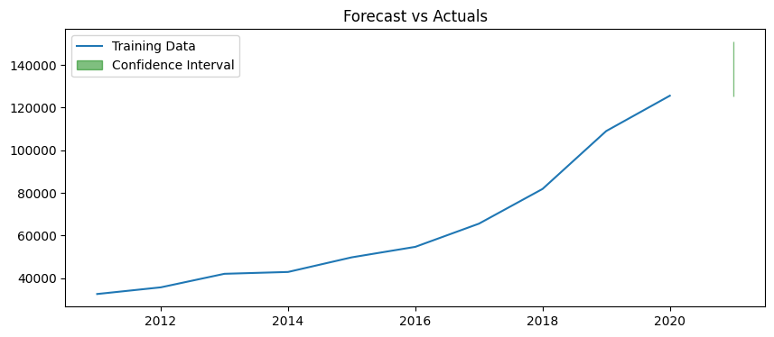

```
O intervalo de confiança estimado foi  [[125018. 150846.]]
```

```python
## PROPOSTA DE MODELO DE SÉRIES TEMPORAIS PARA PREVISÃO DA CRIAÇÃO DE CNPJS NO ANO DE 2021

# Creation of a dataframe that contains the count of opened CNPJ from the year 2010 up to 2020, which will be used to predict 2021
pd.options.mode.chained_assignment = None
import warnings
# Suprimir os avisos
warnings.filterwarnings("ignore")

# Início da modelagem
dfSeries = df.groupby(['opened_at_year'])['document_numberSTR'].count().reset_index().sort_values(['opened_at_year'], ascending=True)
dfSeries = dfSeries[(dfSeries['opened_at_year'] > 2010) & (dfSeries['opened_at_year'] <= 2021)].reset_index(drop=True)
dfSeries.index = dfSeries['opened_at_year']
time_series = dfSeries[['document_numberSTR']]

train_size = int(len(time_series) * 0.93)
train, test = time_series[:train_size], time_series[train_size:]

# Fitting auto_arima model
model = pm.auto_arima(train,
                      start_p=1, start_q=1, # initial p and q
                      max_p=6, max_q=6,     # maximum p and q
                      seasonal=False,       # True for seasonal data
                      trace=True,           # print status
                      error_action='ignore', # ignore errors
                      suppress_warnings=True, # suppress warnings
                      stepwise=True)        # use stepwise search to find best model


# Forecasting the next n_periods
n_periods = len(test)
forecast, conf_int = model.predict(n_periods=n_periods, return_conf_int=True)

# Plotting the forecast along with confidence intervals
plt.figure(figsize=(10, 4))
plt.plot(train, label='Training Data')
plt.fill_between(test.index,
                 conf_int[:, 0], conf_int[:, 1],
                 color='green', alpha=0.5, label='Confidence Interval')
plt.title('Forecast vs Actuals')
plt.legend()
plt.show()
print('O intervalo de confiança estimado foi ', conf_int.round(0))
```